# Python_Final_Project_V2

### IV. Data distribution

Here, we'll see if some features aren't useable in terms of data distribution.

- if the variability is too small
- if scope is too small
- the outliers
- if the distribution is useable (globally)

##### For the global distribution

```
array([[<Axes: title={'center': 'Gender'}>,
        <Axes: title={'center': 'Age'}>,
        <Axes: title={'center': 'Height'}>,
        <Axes: title={'center': 'Weight'}>,
        <Axes: title={'center': 'Family_history_with_overweight'}>],
       [<Axes: title={'center': 'Frequency_eat_high_caloric_food'}>,
        <Axes: title={'center': 'Frequency_eat_vegetables'}>,
        <Axes: title={'center': 'Number_of_main_meals'}>,
        <Axes: title={'center': 'Frequency_eat_between_meals'}>,
        <Axes: title={'center': 'Smoke'}>],
       [<Axes: title={'center': 'Frequency_water'}>,
        <Axes: title={'center': 'Monitoring_calories_consumption'}>,
        <Axes: title={'center': 'Frequency_physical_activity'}>,
        <Axes: title={'center': 'Time_using_technology_devices'}>,
        <Axes: title={'center': 'Frequency_alcohol'}>],
       [<Axes: title={'center': 'Obesity_level_category'}>,
        <Axes: title={'center': 'Main_transport_Automobile'}>,
        <Axes: title={'center': 'Main_transport_Bike'}>,
        <Axes: title={'center': 'Main_transport_Motorbike'}>,
        <Axes: title={'center': 'Main_transport_Public_Transportation'}>],
       [<Axes: title={'center': 'Main_transport_Walking'}>,
        <Axes: title={'center': 'MBI'}>,
        <Axes: title={'center': 'Corrected_obesity_level_category'}>,
        <Axes: >, <Axes: >]], dtype=object)
```

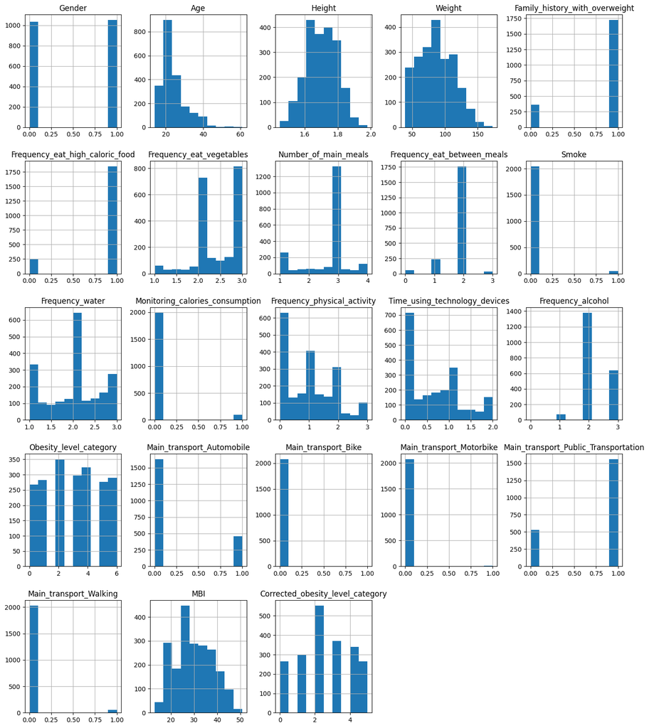

```python
fig, ax = plt.subplots(1, figsize=(17, 20))
df.hist(ax=ax)
```

"Family history with overweight", "Frequency eat high caloric food", "number of main meals", "Smoke" and "monitoring calory consumption" have very concentrated values.

So we will check if these values have a real impact on the target (obesity type). If not, these features won't be necessary (rare and less important events, these caracteritics don't make ML algorithms work efficiently).

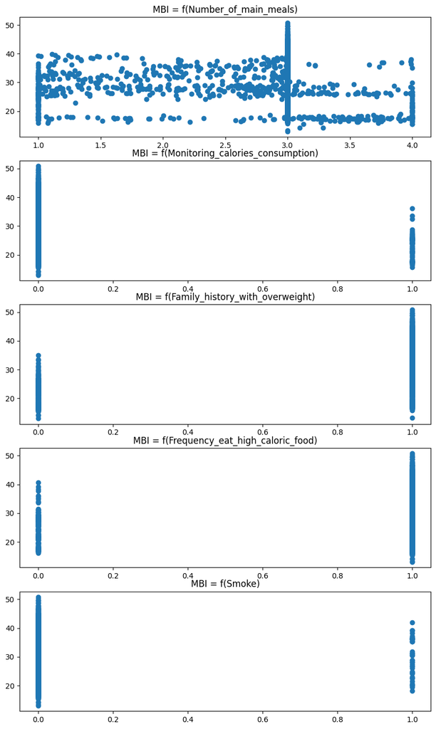

```python
fig, ax = plt.subplots(5,1, figsize=(10,17))
ax[0].scatter(df["Number_of_main_meals"], df["MBI"])
ax[0].set_title("MBI = f(Number_of_main_meals)")
ax[1].scatter(df["Monitoring_calories_consumption"], df["MBI"])
ax[1].set_title("MBI = f(Monitoring_calories_consumption)")
ax[2].scatter(df["Family_history_with_overweight"], df["MBI"])
ax[2].set_title("MBI = f(Family_history_with_overweight)")
ax[3].scatter(df["Frequency_eat_high_caloric_food"], df["MBI"])
ax[3].set_title("MBI = f(Frequency_eat_high_caloric_food)")
ax[4].scatter(df["Smoke"], df["MBI"])
ax[4].set_title("MBI = f(Smoke)")
```

In every graph (except monitoring calory consumption and family history with overweight) we don't see a huge impact of the feature on the result. Given that there are rare event, we won't keep this features.

However, these graphs do not represent the BEST way to show the correlation between the observed features and our target. We will try to find another way to show this later.

```python
# Function to count decimal values in a column
def is_decimal(value):
    if value%1 != 0:
        return True
    else:
        return False

# Apply the function to the specified column
decimal_counts = df['Frequency_water'].apply(lambda x: is_decimal(x))
decimal_counts += df['Number_of_main_meals'].apply(lambda x: is_decimal(x))
decimal_counts += df['Frequency_eat_vegetables'].apply(lambda x: is_decimal(x))
decimal_counts += df['Frequency_physical_activity'].apply(lambda x: is_decimal(x))
decimal_counts += df['Time_using_technology_devices'].apply(lambda x: is_decimal(x))
decimal_counts = decimal_counts.value_counts()
percentage_decimal_water = (100*decimal_counts[0])/df.shape[0]

print(f"there is {decimal_counts[0]} decimal values so it represents {percentage_decimal_water:.2f}%")
print(decimal_counts)
```

```
there is 1580 decimal values so it represents 75.71%
True     1580
False     507
Name: Frequency_water, dtype: int64
```

Fortunately this shouldn't affect too badly our clustering results (shoud be the contrary in fact). We just have to keep in mind that our results will be kind of overfitting (because of the oversampling we overfit the sample of the study (which is small: 485)).

##### The outliers and the scope

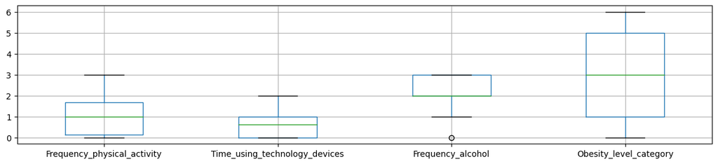

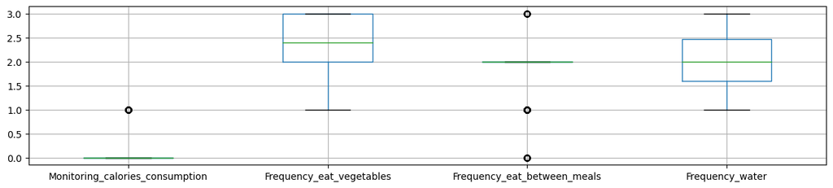

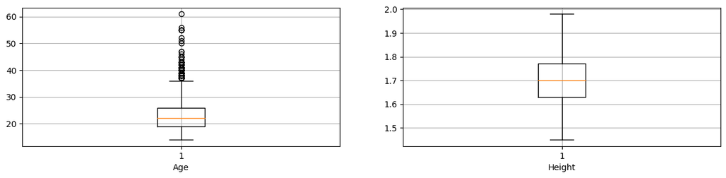

```python
df_scope_1 = df[['Monitoring_calories_consumption', 'Frequency_eat_vegetables',
              'Frequency_eat_between_meals', 'Frequency_water']]
df_scope_2 = df[['Frequency_physical_activity', 'Time_using_technology_devices',
              'Frequency_alcohol', 'Obesity_level_category']]
plt.figure(figsize=(15, 3))
df_scope_2.boxplot(column=['Frequency_physical_activity', 'Time_using_technology_devices',
              'Frequency_alcohol', 'Obesity_level_category'])
plt.show()
plt.figure(figsize=(15, 3))
df_scope_1.boxplot(column=['Monitoring_calories_consumption', 'Frequency_eat_vegetables',
              'Frequency_eat_between_meals', 'Frequency_water'])
plt.show()

fig = plt.figure(figsize=(15,3))
ax1 = fig.add_subplot(1,2,1)
ax2 = fig.add_subplot(1,2,2)
ax1.boxplot(df["Age"])
ax2.boxplot(df["Height"])
ax1.grid()
ax2.grid()
ax1.set_xlabel('Age')
ax2.set_xlabel('Height')
plt.show()
```

There is not relevent outliers to drop (for example for the age it's important to represent the population, the only problem that is shown is that the sample isn't representative for the population)

##### The variability

```python
df[["Age", "Height", "Frequency_physical_activity", "Time_using_technology_devices"]].describe()
```

|  | Age | Height | Frequency_physical_activity | Time_using_technology_devices |
| --- | --- | --- | --- | --- |
| count | 2087.000000 | 2087.000000 | 2087.000000 | 2087.000000 |
| mean | 24.009104 | 1.702616 | 1.012812 | 0.663035 |
| std | 6.333297 | 0.093251 | 0.853475 | 0.608153 |
| min | 14.000000 | 1.450000 | 0.000000 | 0.000000 |
| 25% | 19.000000 | 1.630000 | 0.124505 | 0.000000 |
| 50% | 22.000000 | 1.700000 | 1.000000 | 0.630866 |
| 75% | 26.000000 | 1.770000 | 1.678102 | 1.000000 |
| max | 61.000000 | 1.980000 | 3.000000 | 2.000000 |

We notice a small Standard Deviation for Height, it's because the data has not been normalized yet, but in the boxplots the distribution isn't that problematic. Globally, we don't have STD problems.

##### Data Distribution Conclusion

To sum up, we'll keep all of the features we have for the moment.

Before dropping anything, we will check the correlation for each of them to make sure we're making the right choice.